# Evolution for french first names from 1900 to 2018

Hugo Broucke and Camille Bason

07/12/2019

# Overview and motivation

The French names are very varied, from the most classic fristname to a very unique name. But what is the origin of French firstnames? In the following article we want to study variations of French firstnames and show that they often translate the major French events.

In this report we will first study general statistics on french first names. Then we’ll explain why some names are popular.

You can find a summary of our project [here](https://www.youtube.com/watch?v=I3ItDhnvbdo&feature=youtu.be&fbclid=IwAR3lmYsDMx1JSrAf_Jc2aCBOz1v-h3na8IHqy8tVpEB6mtfYj7A6E_ta5qw). (link to the screencast)

# Related work

Some articles are at the origin of the inspiration of this project. Notably the Website article of [Slate](http://www.slate.fr/life/74937/donnees-prenom-france-evolution) that explains why some firstnames gained or lost in popularity over time and the Website article from [Topito](http://www.topito.com/top-prenoms-autorises-civil-state) that gives weird firstnames (such as “Burger”) that are allowed by civil status.

These articles have given us avenues to explore. We decided to check and explain the appearance of these names through our databases.

# Initial Data

To perform these data analyzes we used three datasets. The first two are datasets from INSEE. one about data for one country (4 features), one about data for regions (5 features): gender of the firstname, firstname, year, occurrence of the name for the given year and region (only for the second dataset).

And one dataset from Eco-health which gives the GDP by French regions per year from 1990 to 2012.

[Link INSEE dataSet](https://www.insee.fr/fr/statistiques/2540004#consulter)

[Link Eco-health dataSet](http://www.ecosante.fr/index2.php?base=DEPA&langs=FRA&langh=FRA&valeur=RICHPIBDFRAHAB&source=1%20&fbclid=IwAR13jACq5EBUSc9wP9xDKVLhftusxUY5YwhSTRnUXOSBL_dLuzQ7jP0XD9U)

# Data

We then modified two datasets to adapt them to our work. These modifications were made on the two datasets of the INSEE. So we deleted all the colons of the rare names that counted these names but did not give the list of these first names. We also deleted the boxes that do not contain a specific year. The names of the labels have been translated into English. The year column has been translated into the “Date” format. Finally, a new “Region” column has been built. Indeed, the firstnames were grouped by French departments. We have grouped these departments by French regions.

```r
knitr::opts_chunk$set(echo = FALSE)
library(readr)
library(tidyverse)
library(plotly)
library(lubridate)
library(ggthemes)

#Importing datasets
data_nat <- read.csv("nat2018_2.csv",sep = ";", encoding = "UTF-8")
data_dpt <- read.csv("dpt2018.csv",sep = ";", encoding = "UTF-8")
eco <- read.csv("eco.csv",sep = ";", encoding = "UTF-8")

#Cleaning data
data_nat_clean <- data_nat %>% filter(!is.na(preusuel)) %>% #Remove empty firstname
  filter(preusuel != "_PRENOMS_RARES") %>% #Remove rare firstnames
  filter(annais != "XXXX") %>% #Remove year 2019
  rename(sex = X.U.FEFF.sexe, year = annais, firstname = preusuel, number = nombre) #Rename variables to english

data_dpt_clean <- data_dpt %>% filter(!is.na(preusuel)) %>%
  filter(preusuel != "_PRENOMS_RARES") %>%
  filter(annais != "XXXX") %>%
  rename(sex = X.U.FEFF.sexe, year = annais, firstname = preusuel, department = dpt, number = nombre)

#Changing the format of year in national data
data_nat_clean$year <- str_pad(data_nat_clean$year,5,"right")
data_nat_clean$year <- str_replace(data_nat_clean$year," ","-31-12")
data_nat_clean$year <- as.Date(data_nat_clean$year, format="%Y-%d-%m")
```

```r
#Creating region dataset
region <-data_dpt_clean %>%
  mutate(region=case_when(
  department %in% c("95", "78", "91", "77","94","92","93","75") ~ "Ile-de-France",
  department %in% c("08","51","10","52") ~ "Champagne-Ardenne",
  department %in% c("02","60","80") ~ "Picardie",
  department %in% c("76", "27") ~ "Haute-normandie",
  department %in% c("18","28","36","37", "41", "45") ~ "Centre",
  department %in% c("14","50","61") ~ "Basse-Normandie",
  department %in% c("21", "58", "71", "89") ~ "Bourgogne",
  department %in% c("59","62") ~ "Nord-Pas-de-Calais",
  department %in% c("54","55","57", "88") ~ "Lorraine",
  department %in% c("67", "68") ~ "Alsace",
  department %in% c("25","39","70","90") ~ "Franche-Comté",
  department %in% c("44","49","53", "72","85") ~ "Pays de la Loire",
  department %in% c("22", "29", "35", "56") ~ "Bretagne",
  department %in% c("16","17","79","86") ~ "Poitou-CharenteS",
  department %in% c("24","33","40","47","64") ~ "Aquitaine",
  department %in% c("09", "12", "31", "32","46","65","81","82") ~ "Midi-Pyrenées",
  department %in% c("19","23","87") ~ "Limousin",
  department %in% c("01","07","26","38","42","69","73","74") ~ "Rhone-Alpes",
  department %in% c("03", "15", "43", "63") ~ "Auvergne",
  department %in% c("11","30","34","48", "66") ~ "Languedoc-Roussillon",
  department %in% c("04","05","06","13", "83","84") ~ "PACA",
  department %in% c("20") ~ "Corse",
  department %in% c("971","972","973","974") ~ "Overseas territories",
))
```

# Exploratory Analysis

## Descriptive analysis

### Unique French names

#### Evolution over time

The first work done was to see the evolution of the number of French first names existing during the twentieth century. We can observe on this first figure that since 1900, there are more and more different French names. However, in recent years there has been a decrease. This can be interpreted as the fact that in recent years, the number of births has been steadily decreasing in France (758 000 in 2018 against nearly 800 000 in 2010), which means that there is less birth and consequently, fewer given names.

In order to analyze in more detail the variations in the number of unique first names, we decided to make a figure showing the difference in percentage of the number of different first names from one year to another.

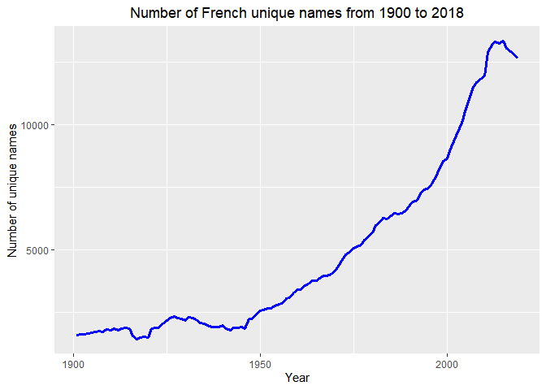

#### Difference between one year to another

According to this figure, we can observe that the evolution of the number of different French first names from one year to another has remained quite stable in a century (variations between -4% and + 4% from one year to another in general). However, we can observe in this figure 3 distinct peaks.

• The first corresponds to a decrease of almost -10% and is in 1915, while the First World War was raging. We can interpret this peak by the fact that the French drastically decreased the birth rate during this period which means that fewer children were born, so fewer names were given. • The other two notable peaks are found in 1919 and 1946 and correspond to increases of almost 10%. This can be explained by the phenomenon of “baby boom” which took place at the end of the two world wars, and because of this, more different names were given since the birth rate was higher.

We can therefore hypothesize that the growth of the birth rate is positively correlated with the number of unique French names given to babies (which seems logical).

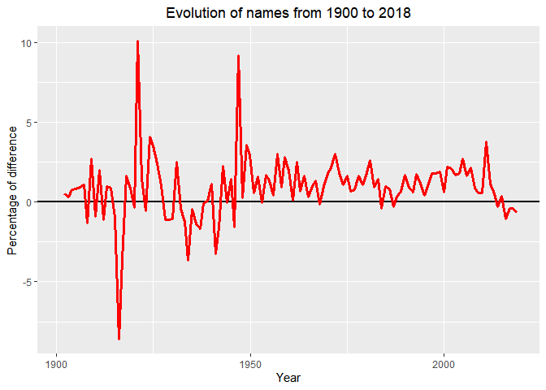

### Most popular names for each region

#### Girls names

This graph represents the most popular names among girls from 1900 to 2018. We observe that from 1900 until 1959, the most popular female name (“Marie”) was the same in each region. Note that the region “Ile de France” (region where the French capital Paris is located), the most popular name has fluctuated from year to year (among the most popular names, we find for example “Jacqueline” in 1932 or “Francoise” in 1948).

The diversity of feminine names between regions began to appear in 1960 when the name “Marie” began to lose popularity giving way to names such as “Catherine” or “Sylvie”. Nowadays, le names “Jade” and “Emma” are the most popular girls’ names in France.

[interactive chart not shown]

#### Boys names

It will be necessary to wait until 1949 to see diversify the names of French boys with the appearance of the names “Michel” or “Philippe” in the top of the given names. Nowadays, there is a clear difference between regions in the popularity of boy given names since we observe no less than 9 different names being the most popular names in the different regions.

To conclude, we have seen in a general way that: • The names of boys were more diverse than those of girls • The region “Ile-de-France” often stands out from the crowd as to the originality of the most popular first name (and also seems to be “avant-garde” because it is often the first region to popularize a given name)

[interactive chart not shown]

## The popularity of Franch Names

In this part we will study which events have an impact on the popularity of French first names.

### French names and sport

In this part we will study the impact of sport on the popularity of French first names. To illustrate this example, we chose to study the most famous sports event in France: the 1998 World Cup. This World Cup was won by the French for the first time.

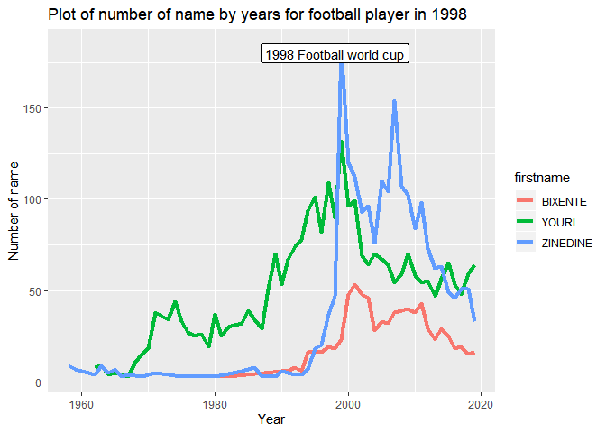

In this graph, we see that the names of three players of the team of France at the 1998 World Cup have a peak of popularity after the victory of France. We can therefore assume that major sports events have an impact on French first names.

### French names and series

The next graph will highlight the impact of TV series on the first name of the French. To illustrate this, we chose one of the best known series in France: *Games of throne*. We can see the names of the famous characters Bran, Daenerys and Sensa.

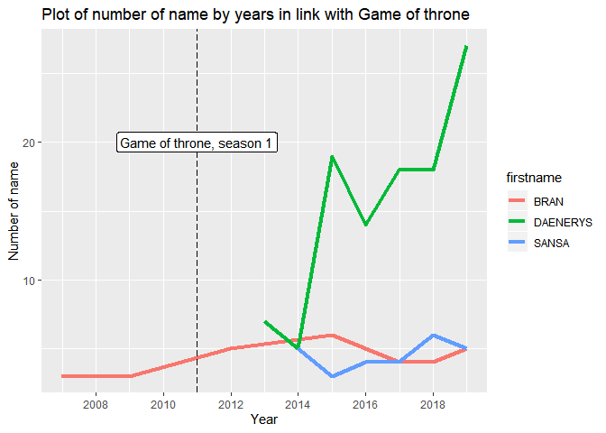

We even observe that the names Daenerys and Sensa appeared just after the diffusion of the series.

### French names and films

In the same spirit as the previous part, we will now observe the impact of films on French firstnames. For that we selected the films *Matrix* with the character of Neo, the movie *Star Wars: Episode I* with e character of Anakin, the movie *The lord of the rings* with Arwen and finally the movie *Twilight* with the name Bella. Besides, the name Bella, the other names appeared in France just after the diffusion of these films. The cinema therefore has an impact on French firstnames.

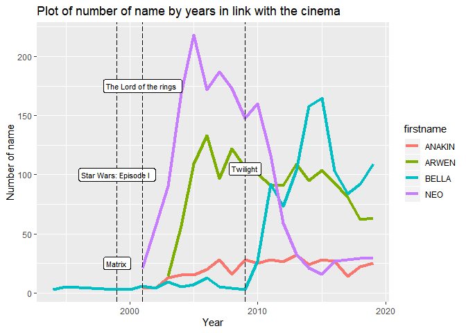

### French names and world wars

One of the most tragic recent events in France is the two world wars. So we decided to see the impact of these wars on the firstnames of the French. One of the heroes of the war is Marchal Joffre, who won the Marne victory. We can see that this victory has an impact on the names of the French since the names Joffre and his feminine Joffrette have a peak of popularity just after this battle.

When we look at the name Victoire, which means victory in French, there are two peaks in 1918 and 1945 which are the dates of the end of these two wars.

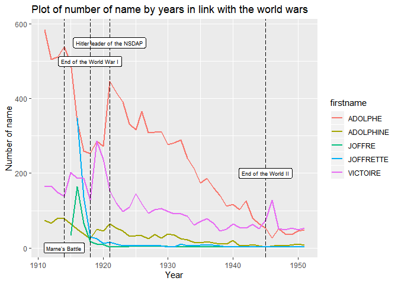

### French names and music

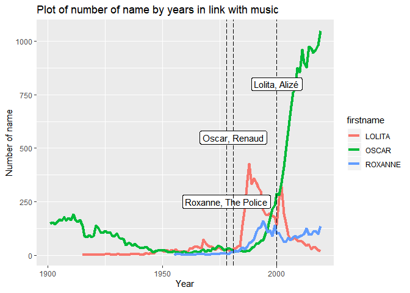

### French names and economy

In this part we will observe if there is a correlation between French firstnames and the economy of the regions. For that we studied the names most given to the little boy and the little girl in 1990, 2000 and 2010 for each French region. The dataset of eco-Health was used to study the GDP of each regions.

#### In 1990

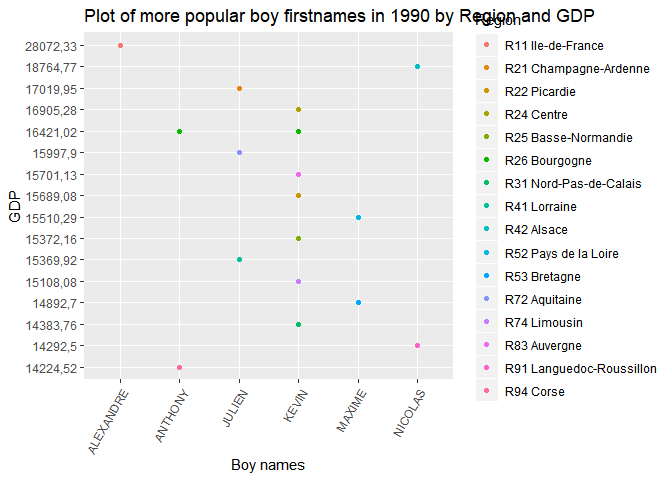

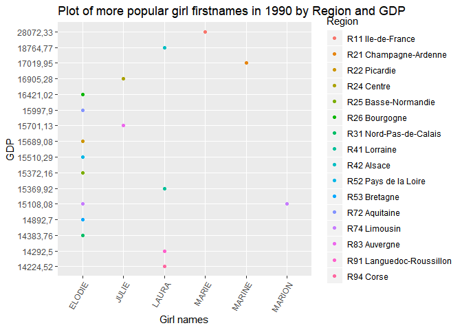

In 1990 we notice that the region Ile de France which is the richest to a popular name differs from other French regions. This is the case for the male and female firstnames.

#### In 2000

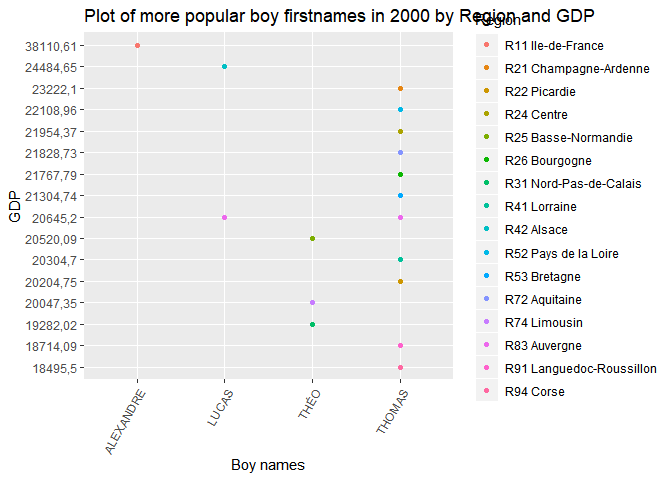

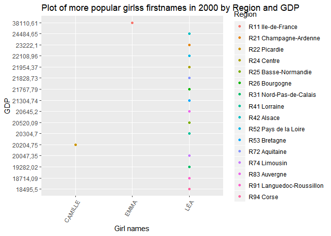

The same phenomenon is observed in 2000.

#### In 2010

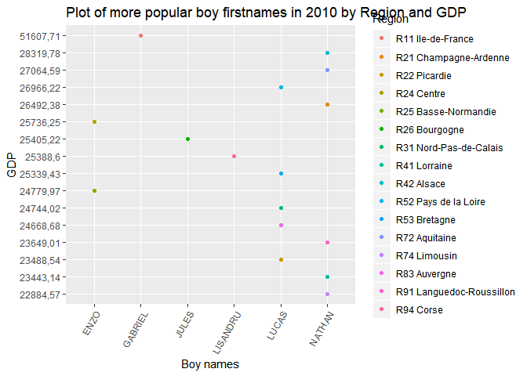

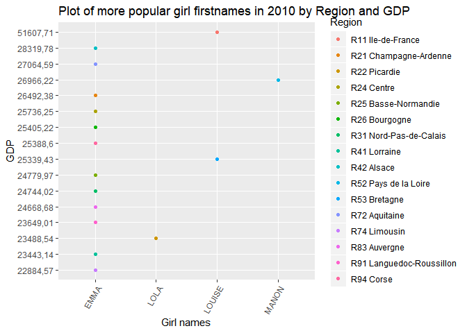

# Final analysis

In this report can understand that the firstnames French illustrates the history of France. We have seen that the geopolitical context, but also the cultural events have an impact on the popularity of French firstnames.

Future work can be done on other countries to see the events that impact the popularity of firstnames.